# Laboratorio 6: Análisis de redes sociales

Se aborda el análisis de datos de redes sociales a partir de dos conjuntos de datos. Con propocito principal de de examinar la estructura de participación de usuarios, la relación entre canales y temas, y el contenido de las conversaciones observadas.

## 1. Carga y procesamiento de datos

```python
import re
import nltk
import pandas as pd
from nltk.corpus import stopwords

# Configuración inicial de NLTK
nltk.download("stopwords")
nltk.download("punkt")

# 1.1 Carga de datos
df_videos = pd.read_csv("youtube_videos.csv")
df_comments = pd.read_csv("youtube_comments.csv")

# 1.4 Integración mediante video_id
df_merged = pd.merge(
    df_comments,
    df_videos,
    on="video_id",
    how="left",
    suffixes=("_comment", "_video"),
)

total_comentarios = len(df_comments)
comentarios_asociados = df_merged["video_id"].notna().sum()
unmapped_comments = df_comments[~df_comments["video_id"].isin(df_videos["video_id"])]

print(f"Total comentarios: {total_comentarios}")
print(f"Comentarios asociados a un video: {comentarios_asociados}")
print(f"Comentarios que no están asociados a un video: {len(unmapped_comments)}")
```

```
Total comentarios: 406
Comentarios asociados a un video: 406
Comentarios que no están asociados a un video: 0
```

#### 1.2 Identificación de estructuras

- **`youtube_videos.csv`**: Unidad de observación: Un video de YouTube. Contiene 293 registros.
  - Llave primaria: video_id.
  - Variables clave: channel_id, category, source_query, view_count, published_time.
- **`youtube_comments.csv`**: Unidad de observación: Un comentario principal. Contiene 406 registros.
  - Llave primaria: comment_id.
  - Llave foránea: video_id.
  - Variables clave: author_channel_id, text, like_count, reply_count.

#### 1.3 Jerarquía y relación lógica

La estructura del dataset sigue una jerarquía relacional donde un canal (channel_id) publica múltiples videos (video_id), los cuales son indexados mediante consultas de búsqueda (source_query) y asociados a una categoría temática. A su vez, los usuarios (author_channel_id) interactúan publicando comentarios (comment_id) dentro de la página de cada video.

#### 1.4 Integración de datos e integridad referencial

Al ejecutar un cruce tabular utilizando la llave video_id, se verificó que el 100% de los comentarios (406 de 406) se asociaron correctamente con su respectivo video en el dataset principal. No se registraron comentarios sin que esten vinculados a un video o desalineados.

## 2. Calidad, limpieza y preprocesamiento

```python
# 2.2 Variables no utilizables / sin variabilidad
vars_to_drop = ["is_pinned", "viewer_rating"]


def clean_text_pipeline(text):
    if not isinstance(text, str):
        return ""
    # Conservar emojis/caracteres pero limpiar formato
    text_clean = text.lower()  # Minúsculas
    text_clean = re.sub(
        r"https?://\S+|www\.\S+", "", text_clean
    )  # Eliminación de URLs
    text_clean = re.sub(r"#\S+", "", text_clean)  # Hashtags
    text_clean = re.sub(r"@\S+", "", text_clean)  # Menciones
    text_clean = re.sub(r"[^\w\s]", "", text_clean)  # Puntuación
    text_clean = re.sub(r"\d+", "", text_clean)  # Números

    # Stopwords en español
    spanish_stopwords = set(stopwords.words("spanish"))
    tokens = text_clean.split()
    tokens = [w for w in tokens if w not in spanish_stopwords]

    return " ".join(tokens)


#Creación de campos
df_comments["texto_original"] = df_comments["text"]
df_comments["texto_limpio"] = df_comments["text"].apply(clean_text_pipeline)

# 2.4 Conversión numérica de métricas
for col in ["view_count"]:
    if col in df_videos.columns and df_videos[col].dtype == "object":
        df_videos[col] = (
            df_videos[col]
            .astype(str)
            .str.replace(r"[^\d]", "", regex=True)
            .astype(float)
        )

#  impacto del procesamiento
vacios_antes = df_comments["texto_original"].isna().sum()
vacios_despues = (df_comments["texto_limpio"].str.strip() == "").sum()
duplicados_limpios = df_comments["texto_limpio"].duplicated().sum()

print(f"Comentarios vacíos tras limpieza: {vacios_despues}")
print(f"Textos duplicados tras limpieza: {duplicados_limpios}")
```

```
Comentarios vacíos tras limpieza: 6
Textos duplicados tras limpieza: 11
```

```python
df_real = df_merged if 'texto_limpio' in df_merged.columns else df_comments

col_original = [c for c in ['comment_text', 'textOriginal', 'text', 'texto'] if c in df_real.columns]
cols_a_mostrar = col_original + ['texto_limpio'] if col_original else ['texto_limpio']

vacios = df_real[df_real['texto_limpio'].str.strip() == ''][cols_a_mostrar]
print("--- COMENTARIOS QUE QUEDARON VACÍOS ---")
print(vacios.head(10))

# 4. Mostrar duplicados
duplicados = df_real[df_real.duplicated(subset=['texto_limpio'], keep=False) & (df_real['texto_limpio'] != '')]
print("\n--- EJEMPLOS DE TEXTOS DUPLICADOS TRAS LIMPIEZA ---")
print(duplicados[cols_a_mostrar].sort_values(by='texto_limpio').head(10))
```

```
--- COMENTARIOS QUE QUEDARON VACÍOS ---
                         text texto_limpio
38                          😮
49                         ❤🎉
97                       que?
129                        😂😂
139   @Murmullodelbarrio 👍🇬🇹
187                    👏👏👏👏👏👏

--- EJEMPLOS DE TEXTOS DUPLICADOS TRAS LIMPIEZA ---
                                                  text  \
116  Ahora se destapo la CORRUPCION Q EXISTIA Y AHO...
324  Ahora se destapo la CORRUPCION Q EXISTIA Y AHO...
174  TODO EL APOYO PARA EL PRESIDENTE BERNARDO AREV...
219  TODO EL APOYO PARA EL PRESIDENTE BERNARDO AREV...
```

[output cut: 18 more lines]

### Variables no utilizables

2.2 Variables que no pueden utilizarse o que requieren precauciones especiales

- `is_pinned`: Se descarta del análisis por presentar variabilidad nula
- `viewer_rating`: Se excluye debido a que está completamente vacía
- `published_time` y `view_count_text`: Se tratan con precaución por ser representaciones textuales/relativas; para cálculos se utiliza únicamente la versión numérica estandarizada (`view_count`).
- `author_name` y `channel_name`: Se reservan únicamente como etiquetas de visualización. Todas las agrupaciones, identificaciones y aristas de la red se basan en `author_channel_id` y `channel_id` para prevenir sesgos por nombres cambiantes o duplicados.

2.7 Registros eliminados o modificados, textos vacíos y duplicados antes y después. Los comentarios vacios (6) sucedieron dado que los textos que contenian emojis, menciones con emojis; al remover estas palabras queda una cadena vacía ("")

Los textos duplicados son 11, se paso de minúsculas y elmina caracteres especiales. Se unificó variaciones de los comentarios como "EXCELENTE", "excelente", "Excelente.", tanformandose solamente en "excelente". Además textos como " Exelente 👌", se les eliminó el emoji.

## 3. Análisis exploratorio

```python
import pandas as pd
from collections import Counter
import re

# 1. Conteo de entidades
n_videos = df_videos['video_id'].nunique() if 'video_id' in df_videos.columns else len(df_videos)
col_canal = 'channel_id' if 'channel_id' in df_videos.columns else ('channel_name' if 'channel_name' in df_videos.columns else None)
n_canales = df_videos[col_canal].nunique() if col_canal else df_comments['channel_id'].nunique()
n_comentarios = len(df_comments)
col_autor = 'author_channel_id' if 'author_channel_id' in df_comments.columns else ('author_name' if 'author_name' in df_comments.columns else 'author')
n_autores = df_comments[col_autor].nunique()

# 2. Promedios y Distribuciones
v_por_canal = df_videos.groupby(col_canal)['video_id'].nunique() if col_canal else pd.Series()
c_por_video = df_comments.groupby('video_id')['text'].count()
a_por_video = df_comments.groupby('video_id')[col_autor].nunique()

# 3. Métricas de interacción (views, likes, respuestas)
col_views = [c for c in ['view_count', 'views', 'viewCount'] if c in df_videos.columns]
col_likes = [c for c in ['like_count', 'likes', 'likeCount'] if c in df_comments.columns or c in df_videos.columns]
col_reply = [c for c in ['reply_count', 'replies', 'replyCount'] if c in df_comments.columns]

views_totales = df_videos[col_views[0]].sum() if col_views else "N/A"
likes_comentarios = df_comments[col_likes[0]].sum() if (col_likes and col_likes[0] in df_comments.columns) else "N/A"
respuestas_totales = df_comments[col_reply[0]].sum() if col_reply else "N/A"

# 4. Palabras y Bigramas frecuentes sobre texto_limpio
palabras = " ".join(df_comments['texto_limpio'].dropna()).split()
top_palabras = Counter(palabras).most_common(10)

bigramas = zip(palabras[:-1], palabras[1:])
top_bigramas = Counter(bigramas).most_common(10)


print(f"• Videos: {n_videos} | Canales: {n_canales} | Comentarios: {n_comentarios} | Autores únicos: {n_autores}")
print(f"• Promedio de videos por canal: {v_por_canal.mean():.2f} (Máx: {v_por_canal.max()}, Mín: {v_por_canal.min()})")
print(f"• Promedio de comentarios por video: {c_por_video.mean():.2f}")
print(f"• Promedio de autores únicos por video: {a_por_video.mean():.2f}")
print(f"• Visualizaciones totales en videos: {views_totales}")
print(f"• Me gusta totales en comentarios: {likes_comentarios}")
print(f"• Respuestas totales en comentarios: {respuestas_totales}")
print("\n• Top 5 Palabras frecuentes:", top_palabras[:5])
print("• Top 5 Bigramas frecuentes:", top_bigramas[:5])
```

```
• Videos: 293 | Canales: 97 | Comentarios: 406 | Autores únicos: 332
• Promedio de videos por canal: 3.02 (Máx: 32, Mín: 1)
• Promedio de comentarios por video: 21.37
• Promedio de autores únicos por video: 18.05
• Visualizaciones totales en videos: 17706015
• Me gusta totales en comentarios: N/A
• Respuestas totales en comentarios: 51

• Top 5 Palabras frecuentes: [('si', 73), ('pueblo', 54), ('guatemala', 50), ('dinero', 34), ('solo', 33)]
• Top 5 Bigramas frecuentes: [(('presidente', 'bernardo'), 9), (('bernardo', 'arevalo'), 8), (('ciudad', 'guatemala'), 6), (('nery', 'rodas'), 5), (('bla', 'bla'), 5)]
```

3.1 Descripción

- Hay 293 videos en 97 canales, en promedio 3.02, hay canales con mucha interacción, contando con hasta 32 videos, hay 406 comentarois con 332 autores unicos, por lo que son pocos los usuaros lo que comentan repetidamente en los videos.
- El 12.5% de todos los comentarios son respuestas directas a otros comentarios, lo que muestra que hay hilos de discusión y no solo comentarios aislados al creador del video.
- Las visualizaciones totales superan los 17.7 millones ($17,706,015$). Comparar $17.7$M de vistas contra solo $406$ comentarios demuestra la inmensa mayoría de la audiencia es un público pasivo que solo consume el contenido sin comentar.
- Las palabras mas frecuentes son: si (73), pueblo (54), guatemala (50), dinero (34), solo (33).
- Bigramas: 'presidente', 'bernardo') (9), ('bernardo', 'arevalo') (8), ('ciudad', 'guatemala') (6), ('nery', 'rodas') (5). Mostrando que las convesaciones tratan de temas políticos.

```
=== 3.2 ANÁLISIS DE CONCENTRACIÓN ===
• Top 10% de videos (30 videos) concentran: 100.00% de comentarios
• Top 10% de canales (10 canales) concentran: 100.00% de comentarios

=== 3.3 CORRELACIÓN POPULARIDAD VS PARTICIPACIÓN ===
• Correlación de Pearson (Vistas vs Comentarios): -0.0084
• Correlación de Spearman (Rangos): 0.0803
```

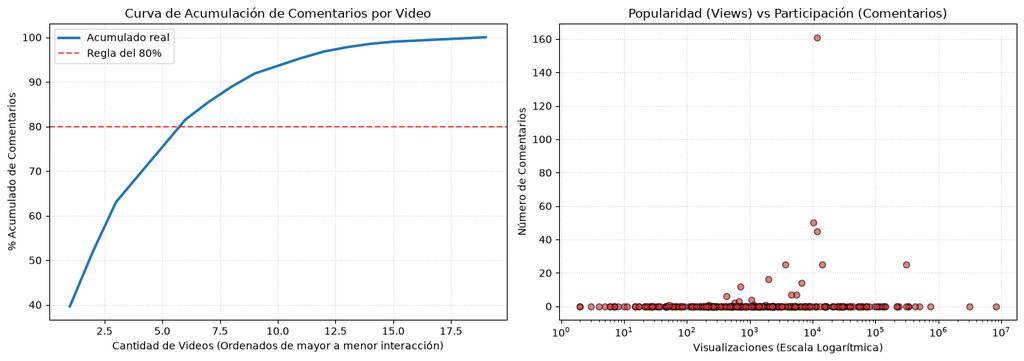

```python
import pandas as pd
import numpy as np
import matplotlib.pyplot as plt

# Configuracion de columnas
col_canal = 'channel_id' if 'channel_id' in df_videos.columns else ('channel_name' if 'channel_name' in df_videos.columns else 'channel_id')
col_views = [c for c in ['view_count', 'views', 'viewCount'] if c in df_videos.columns][0]

# Pareto por videos y canales
comments_per_video = df_comments['video_id'].value_counts()
n_videos_totales = df_videos['video_id'].nunique()

top_10_percent_v_count = int(np.ceil(0.10 * n_videos_totales))
top_10_v_comments = comments_per_video.head(top_10_percent_v_count).sum()
pct_pareto_videos = (top_10_v_comments / len(df_comments)) * 100

comments_per_channel = df_comments[col_canal].value_counts()
n_canales_totales = df_videos[col_canal].nunique()

top_10_percent_c_count = int(np.ceil(0.10 * n_canales_totales))
top_10_c_comments = comments_per_channel.head(top_10_percent_c_count).sum()
pct_pareto_canales = (top_10_c_comments / len(df_comments)) * 100

print("=== 3.2 ANÁLISIS DE CONCENTRACIÓN ===")
print(f"• Top 10% de videos ({top_10_percent_v_count} videos) concentran: {pct_pareto_videos:.2f}% de comentarios")
print(f"• Top 10% de canales ({top_10_percent_c_count} canales) concentran: {pct_pareto_canales:.2f}% de comentarios")

# Correlacion popularidad vs participacion
comments_count_df = df_comments.groupby('video_id').size().reset_index(name='n_comentarios')
df_pop = pd.merge(df_videos[['video_id', col_views]], comments_count_df, on='video_id', how='left').fillna({'n_comentarios': 0})

corr_pearson = df_pop[col_views].corr(df_pop['n_comentarios'])
corr_spearman = df_pop[col_views].corr(df_pop['n_comentarios'], method='spearman')

print("\n=== 3.3 CORRELACIÓN POPULARIDAD VS PARTICIPACIÓN ===")
print(f"• Correlación de Pearson (Vistas vs Comentarios): {corr_pearson:.4f}")
print(f"• Correlación de Spearman (Rangos): {corr_spearman:.4f}")

# Graficos explicativos
fig, axes = plt.subplots(1, 2, figsize=(14, 5))

# Curva acumulada
sorted_comments = np.sort(comments_per_video.values)[::-1]
cum_pct = np.cumsum(sorted_comments) / len(df_comments) * 100

axes[0].plot(range(1, len(cum_pct) + 1), cum_pct, color='#1f77b4', lw=2.5, label='Acumulado real')
axes[0].axhline(80, color='r', linestyle='--', alpha=0.7, label='Regla del 80%')
axes[0].set_title('Curva de Acumulación de Comentarios por Video', fontsize=12)
axes[0].set_xlabel('Cantidad de Videos (Ordenados de mayor a menor interacción)')
axes[0].set_ylabel('% Acumulado de Comentarios')
axes[0].grid(True, linestyle=':', alpha=0.6)
axes[0].legend()

# Dispersion Views vs Comentarios
axes[1].scatter(df_pop[col_views], df_pop['n_comentarios'], color='#d62728', alpha=0.6, edgecolors='k')
axes[1].set_title('Popularidad (Views) vs Participación (Comentarios)', fontsize=12)
axes[1].set_xlabel('Visualizaciones (Escala Logarítmica)')
axes[1].set_ylabel('Número de Comentarios')
axes[1].set_xscale('log')
axes[1].grid(True, linestyle=':', alpha=0.6)

plt.tight_layout()
plt.show()
```

3.2 Concentración de la participación.

Un pequeño porcentaje de los contenidos atrae la gran mayoría de la actividad, mientras que una larga cola (long tail) de videos presenta baja o nula interacción.

La conversación no está distribuida uniformemente en el corpus. El $90\%$ restante de los contenidos del dataset no cuenta con comentarios, lo que evidencia que el debate público generado en esta muestra se focaliza exclusivamente en un reducido grupo de videos y creadores de alto impacto.

3.3 popularidad y participación. No existe una relación lineal entre el número de visualizaciones que recibe un video y la cantidad de comentarios que obtiene.

  YouTube impone un número máximo de consultas diarias. Esto no permite descargar absolutamente todos los comentarios de cada video, sino solo una muestra, lo que puede dejar fuera discusiones secundarias.

  Solo analizamos los comentarios que estaban visibles al momento de descargar la información

## 4. Construcción de la red bipartita autor-video

```
=== MÉTRICAS DE LA RED BIPARTITA ===
• Total de nodos: 351 (332 usuarios, 19 videos)
• Total de aristas (interacciones únicas): 343
• ¿Es una red bipartita válida?: True

=== PROYECCIÓN DE VIDEOS (AUDIENCIAS COMPARTIDAS) ===
• Nodos en red proyectada (Videos): 19
• Aristas (Pares de videos que comparten comentaristas): 11
```

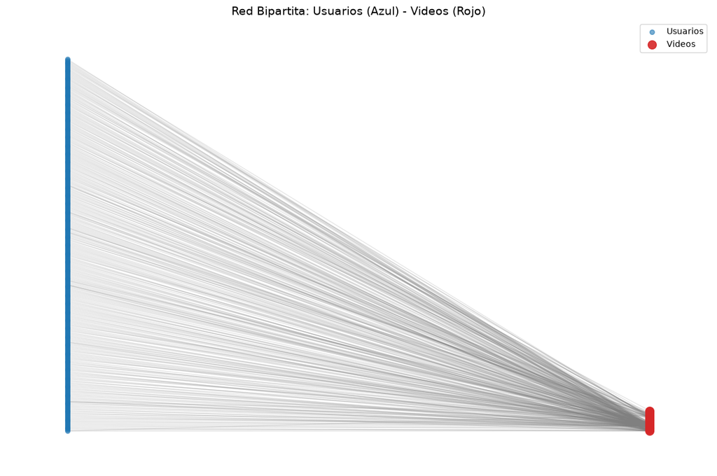

```python
import networkx as nx
import pandas as pd
import matplotlib.pyplot as plt
from networkx.algorithms import bipartite

# 1. Crear grafo bipartito
G = nx.Graph()

# Identificar nodos de usuarios y videos
usuarios = df_comments['author_id'].dropna().unique() if 'author_id' in df_comments.columns else df_comments['author_name'].dropna().unique()
col_autor = 'author_id' if 'author_id' in df_comments.columns else 'author_name'
videos = df_comments['video_id'].dropna().unique()

# Agregar nodos con atributo de tipo
G.add_nodes_from(usuarios, bipartite=0, type='usuario')
G.add_nodes_from(videos, bipartite=1, type='video')

# Agregar aristas (interacciones usuario-video)
edges = df_comments[[col_autor, 'video_id']].dropna().drop_duplicates().values
G.add_edges_from(edges)

print("=== MÉTRICAS DE LA RED BIPARTITA ===")
print(f"• Total de nodos: {G.number_of_nodes()} ({len(usuarios)} usuarios, {len(videos)} videos)")
print(f"• Total de aristas (interacciones únicas): {G.number_of_edges()}")
print(f"• ¿Es una red bipartita válida?: {bipartite.is_bipartite(G)}")

# 2. Proyección sobre los Videos (Conexión por usuarios compartidos)
# Crea un enlace entre dos videos si comparten al menos un autor en común
G_videos = bipartite.weighted_projected_graph(G, videos)

print("\n=== PROYECCIÓN DE VIDEOS (AUDIENCIAS COMPARTIDAS) ===")
print(f"• Nodos en red proyectada (Videos): {G_videos.number_of_nodes()}")
print(f"• Aristas (Pares de videos que comparten comentaristas): {G_videos.number_of_edges()}")

# 3. Visualización de la Red Bipartita
plt.figure(figsize=(12, 8))

# Posicionamiento especial para grafos bipartitos
pos = {}
pos.update((node, (1, index)) for index, node in enumerate(usuarios))
pos.update((node, (2, index)) for index, node in enumerate(videos))

# Dibujar nodos por categoría
nx.draw_networkx_nodes(G, pos, nodelist=usuarios, node_color='#1f77b4', node_size=30, alpha=0.6, label='Usuarios')
nx.draw_networkx_nodes(G, pos, nodelist=videos, node_color='#d62728', node_size=100, alpha=0.9, label='Videos')
nx.draw_networkx_edges(G, pos, alpha=0.2, edge_color='gray')

plt.title('Red Bipartita: Usuarios (Azul) - Videos (Rojo)', fontsize=14)
plt.axis('off')
plt.legend()
plt.tight_layout()
plt.show()
```